# Assignment 3 - The free position facility location problem

Riboni Alessandro

28 May 2019

## The Problem

In this assignment we will look at the **Facility Location Problem**. The problem can be described in general terms as follows:

We must decide the placement of a facility that distributes a certain good to a group of consumers that need it.

The placement must to be chosen in order to **minimize** the total compound distance from the facility and the customers.

The following assumptions has to be taken into account:

1. The possible location for the facility is unknown, that is the problem is to find the right spot to build it.
2. The facility building costs are fixed and independent from the position of the building site.

Notice that in this scenario there is one possible decision to make:

- where to build the facility, that is find the position ($\chi$, $\upsilon$) that minimises the compound distance of the facility with respect to all custumers.

### Data

A file with the locations of the consumers can be found in the `Data` folder.

## Distance function

Given the position of the facility $f= (\chi, \upsilon)$ and of a consumer $p_i=(x_i, y_i)$ use the following formula to calculate the distance between them.

$$d(f,p_i) = log((\chi-x_i)^2+1) + log((\upsilon-y_i)^2+1)$$

## The assignment

### 1. Formulate the objective function to minimize for the described problem.

Considerando le specifiche del problema, possiamo formulare la funzione obiettivo per minimizzare la distanza della facility in base alle posizioni dei clienti nel seguente modo:

$$min \big( \sum_{i=1}^{100} d(f,p_i) \big) = min \big(\Delta(\chi, \nu)\big) = min\big(\sum_{i=1}^{100} ( log[(\chi-x_i)^2+1] + log[(\upsilon-y_i)^2+1] )\big)$$

### 2. Express in analytical form the gradient for the objective to minimize.

Per calcolare il gradiente di $\Delta(\chi,\nu)$, è necessario calcolare le due derivate parziali rispetto alle variabili $\chi$ e $\nu$:

$$\frac{\partial(\Delta(\chi,\nu))}{\partial\chi} = 2\cdot \sum_{i=1}^{100} \frac{( \chi - x_i)}{(\chi - x_i)^2 +1}$$
$$\frac{\partial(\Delta(\chi,\nu))}{\partial\nu} = 2\cdot \sum_{i=1}^{100} \frac{( \nu - y_i)}{(\nu - y_i)^2 +1}$$

Di conseguenza, il gradiente di $\Delta(\chi,\nu)$ può essere scritto come:

$$\nabla (\Delta(\chi, \nu)) = \Bigg (\matrix{ \frac{\partial(\Delta(\chi,\nu))}{\partial\chi} \\ \frac{\partial(\Delta(\chi,\nu))}{\partial\nu}} \Bigg ) = 2\cdot \Bigg (\matrix{ \sum_{i=1}^{100} \frac{( \chi - x_i)}{(\chi - x_i)^2 +1} \\ \sum_{i=1}^{100} \frac{( \nu - y_i)}{(\nu - y_i)^2 +1}} \Bigg )$$

### 3. Implement the `Gradiend Descent method` and solve the problem with it.

Per implementare il `Gradiend Descent method` abbiamo definito:  
- la funzione che ritorna il gradiente (fn.gr), la quale prende in input le posizioni dei clienti e i valori di $\chi$ e $\nu$.  
- una funzione che calcola la norma euclidea: $||(\chi, \nu)||= \sqrt{\chi^2 + \nu^2}$  
- la funzione che calcola la distanza dalle posizioni dei clienti

```r
df <- read.csv("/Users/alessandro/Desktop/consumer_locations.csv", sep = ",")

X <- data.matrix(df, rownames.force = NA)

fn.dist <- function(X, par) return(sum(log((par[1]-X[,1])^2+1)) + sum(log((par[2]-X[,2])^2+1)))

# gradient function
fn.gr <- function(X, par) {
  g1 <- sum(2*(par[1]-X[,1])/((par[1]-X[,1])^2+1))
  g2 <- sum(2*(par[2]-X[,2])/((par[2]-X[,2])^2+1))
  return(c(g1,g2))
}

# euclidean norm function
fn.norma <- function(x) return(sqrt(sum((x)^2)))

# gradient descent function
gradientDescent <- function(X, par.init, fun.gr, lr, iters, tol){
  par <- matrix(NA, nrow = iters+1, ncol = 2)
  grad_dist <- matrix(NA, nrow = iters+1, ncol = 2)
  par[1,] <- par.init
  for(k in 1:iters){
    grad_dist[k,] <- fun.gr(X=X, par=par[k,])
    par[k+1,] <- par[k,] - lr*grad_dist[k,]
    if(fn.norma(grad_dist[k,])<=tol){
        return(par[k,])
    }
  }
  stringa <- "Non ho trovato il minimo"
  return(stringa)
}
```

Un punto viene considerato di minimo locale se la norma del gradiente in tale punto è minore di una specifica tolleranza ($tol = 0.00001$).  
Se questa condizione non viene mai soddisfatta nelle $n$ iterazioni significa che l’algoritmo non è stato in grado di trovare un punto di minimo locale.

Partendo da un punto iniziale casuale di $\chi$ e $\nu$ si calcola il `Gradient Descent`:

```r
part <- c(runif(1,1,1000), runif(1,1,1000))

facility <- gradientDescent(X, par.init = part, fun.gr = fn.gr, lr = 0.1, iters = 1000, tol = 0.00001)
if (is.numeric(class(facility))) {
  d <- fn.dist(X, facility)
  print(d)
} else {
  print(facility)
}
```

```
## [1] 187.0026 636.6707
```

Tale metodo è molto sensibile alla scelta del parametro iniziale. Inoltre, studiando la nostra funzione obiettivo, abbiamo constatato che possiede numerosi punti di minimo locale. Avendo come obiettivo quello di minimizzare la distanza della facility dalla posizione dei clienti abbiamo provato ad iterare il metodo implementato più volte (cambiando il punto iniziale), tenendo come punto ottimale $(\chi,\nu)$ quello che minimizzava tale distanza.

Inizialmente abbiamo iterato il `Gradiend Descent method`, cambiando in modo casuale il punto iniziale.

```r
repeat {
  part <- c(runif(1,1,1000), runif(1,1,1000))
  facility <- gradientDescent(X, par.init = part, fun.gr = fn.gr, lr = 0.1, iters = 1000, tol = 0.00001)
  if (class(facility) == "numeric")
    break
}

d <- fn.dist(X, facility)
for (i in 1:1000) {
  par_init<- c(runif(1,1,1000), runif(1,1,1000))
  facility <- gradientDescent(X, par.init = par_init, fun.gr = fn.gr, lr = 0.1, iters = 1000, tol = 0.00001)
  if (class(facility) == "numeric") {
    if (fn.dist(X,facility) < d) {
        d <- fn.dist(X,facility)
        fac_optimal_r <- facility
    }
  }
}
print(c(x = fac_optimal_r[1], y = fac_optimal_r[2], distance = d))
```

```
##         x         y  distance
##  310.1627  430.8702 2004.9642
```

La norma euclidea è molto vicina allo zero, ci conferma che abbiamo trovato un punto di minimo:

```r
fn.norma(fn.gr(X=X,fac_optimal_r))
```

```
## [1] 9.172395e-06
```

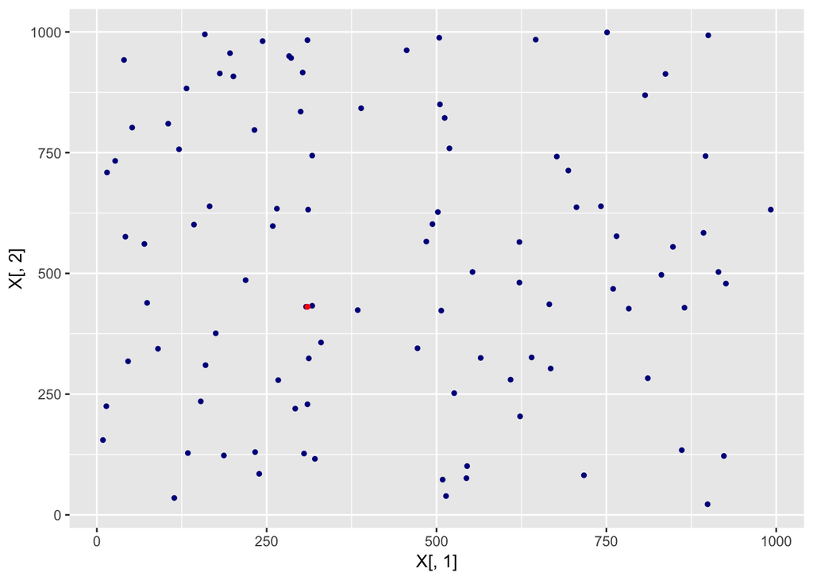

```r
fac_optimal_df <- as.data.frame(fac_optimal_r)
g <- ggplot() +
  # blue plot
    geom_point(data=df, aes(x = X[,1], y = X[,2]),fill="blue",colour="darkblue", size=1 ) +
  # red plot
    geom_point(data=fac_optimal_df, aes(x = fac_optimal_df[1,], y = fac_optimal_df[2,]), fill="red", colour="red", size=1)
g
```

Successivamente abbiamo provato ad utilizzare come punti di partenza le posizioni dei clienti. Iterando meno volte il metodo, riusciamo a trovare una distanza minore (o uguale) al caso precedente.

```r
repeat {
  facility <- gradientDescent(X, par.init = part, fun.gr = fn.gr, lr = 0.1, iters = 1000, tol = 0.00001)
  if (class(facility) == "numeric")
    break
}

d <- fn.dist(X, facility)
for (i in 1:100) {
  par_init <- c(X[i,1],X[i,2])
  facility <- gradientDescent(X, par.init = par_init, fun.gr = fn.gr, lr = 0.1, iters = 1000, tol = 0.00001)
  if (class(facility) == "numeric") {
    if (fn.dist(X,facility) < d) {
        d <- fn.dist(X,facility)
        fac_optimal <- facility
    }
  }
}
print(c(x = fac_optimal[1], y = fac_optimal[2], distance = d))
```

```
##         x         y  distance
##  310.1627  430.8703 2004.9642
```

La norma euclidea è molto vicina allo zero:

```r
fn.norma(fn.gr(X=X,fac_optimal))
```

```
## [1] 9.856868e-06
```

In entrambi i casi abbiamo il gradiente nullo, ma nel secondo riusciamo ad ottenere un minimo che rende minima la distanza: $(\chi_{min},\nu_{min})=(310.1627 , 430.8703)$, $\Delta_{min} = 2004.9642$

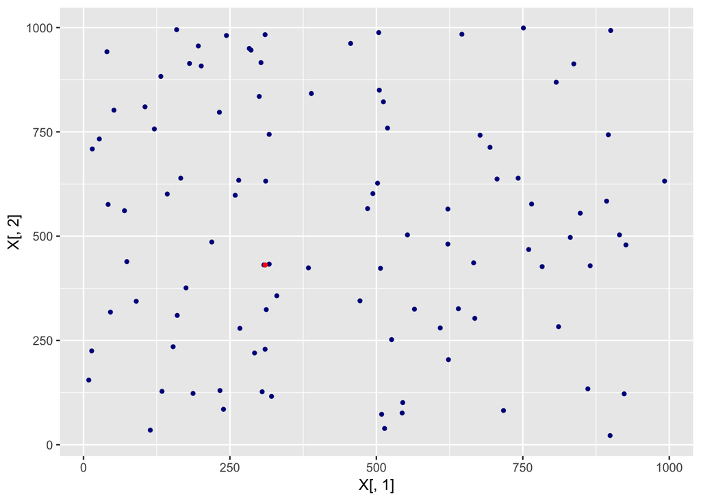

```r
fac_optimal_df <- as.data.frame(fac_optimal)
g <- ggplot() +
  # blue plot
    geom_point(data=df, aes(x = X[,1], y = X[,2]),fill="blue",colour="darkblue", size=1) +
  # red plot
    geom_point(data=fac_optimal_df, aes(x = fac_optimal_df[1,], y = fac_optimal_df[2,]), fill="red", colour="red", size=1)
g
```

### 4. Solve the problem with a package provided by R (for instance, using the function `optimr` within the package `optimx`). Note that it is not required to use the `gradient descent` algorithm to solve the problem, other algorithms can be used as well.

Risolviamo il problema utlizzando la funzione `optimr` con il metodo `Conjugate Gradient`:

```r
library(curry)

fun.gr_1  <- curry(fun = fn.gr, X)
fun.dist <- curry(fun = fn.dist, X)

library(optimx)
strt <- part
ansfgh <- optimr(par = strt, fn = fun.dist, gr = fun.gr_1,method="CG")
opt_CG <- ansfgh


for (i in 1:100) {
  strt <- c(X[i,1],X[i,2])
  ansfgh <- optimr(par = strt, fn = fun.dist, gr = fun.gr_1,method="CG")
  if(ansfgh$value < opt_CG$value) {
    opt_CG <- ansfgh
  }

}
proptimr(opt_CG)
```

```
## Result  opt_CG   proposes optimum function value = 2004.964  at parameters
##        x        y
## 310.1627 430.8702
## After  61  fn evals, and  25  gr evals
## Termination code is  0 :
## ---------------------------------------
```

Utilizzando come punti iniziali le posizioni dei clienti si può notare che i risultati ottenuti sono praticamente identici a quelli ottenuti precedentemente.  
Anche in questo caso, la scelta del parametro iniziare incide molto sul risultato finale.

### 5. Implement the `Stochastic gradient descent` algorithm with mini-batches and use it to solve the problem.

Definiamo lo `Stochastic gradient descent`con mini-batches equivalenti al $5\%$ della dimensione del dataset.  
Ad ogni iterazione viene generato un campione random e per ogni punto ottenuto viene calcolata la distanza.  
La funzione ritorna il punto che rende minima la distanza.

```r
# define stochastic gradient descent algorithm
stoch_gradDescent <- function(X, par.init, fun.gr, lr, iters){

  # Initialize a matrix to store values of par for each iteration
  parIter <- matrix(NA, nrow = iters, ncol = 2)
  distIter <- matrix(NA, nrow = iters, ncol = 1)
  parIter[1, ] <- par.init

  # now iterate using mini batches of randomly sampled  data,
  for (i in 2:iters) {

    xysamp <- as.matrix( X[sample(nrow(X), 5, replace = TRUE), ])
    parIter[i, ] <- parIter[i-1, ]- lr  * fun.gr(xysamp, parIter[i-1,])
    distIter[i] <- fn.dist(X, parIter[i,])

  }

  d_min <- fn.dist(X, parIter[1,])
  par_opt <- parIter[1,]
  for(i in 2:iters) {
    if( distIter[i] < d_min){
      d_min <- distIter[i]
      par_opt <- parIter[i,]
    }
  }
  return(c(x = par_opt[1], y = par_opt[2], d = d_min))
}

part <- c(runif(1,1,1000), runif(1,1,1000))
result <- stoch_gradDescent(X = X, par.init = part, fun.gr = fn.gr,lr = 0.1, iters = 1000)
result
```

```
##          x          y          d
##  700.19866   15.16531 2280.87151
```

Iteriamo più volte la funzione in modo da partire da diversi punti iniziali di $\chi$ e $\nu$. Anche nel caso stocastico è possibile partire da punti casuali o dalle posizioni dei clienti. Come nel caso precedente, il secondo caso permette di trovare una distanza minore o uguale rispetto al primo.

A causa del limitato numero di osservazioni presenti nel dataset iniziale, l’utilizzo del metodo stocastico non porta ad un aumento delle prestazioni. Anzi, inserendo il controllo sulla distanza anche all’interno della funzione $stoch gradDescent$ per essere certi di ottenere il punto che minimizza la nostra funzione obiettivo, il tempo di computazione aumenta.

```r
part <- c(runif(1,1,1000), runif(1,1,1000))
result <- stoch_gradDescent(X = X, par.init = part, fun.gr = fn.gr,lr = 0.1, iters = 1000)
d_stoch <- result["d"]

for (i in 1:100) {
  part<- c(X[i,1],X[i,2])
  result <- stoch_gradDescent(X, part, fn.gr, 0.1,1000)

  if (result["d"] < d_stoch) {
    d_stoch <- result["d"]
    result_opt<- c(result["x"],result["y"])
  }
}


print(c(facility = result_opt, distance = d_stoch))
```

```
## facility.x facility.y distance.d
##   310.1476   430.8715  2004.9646
```

```r
part <- c(runif(1,1,1000), runif(1,1,1000))
result <- stoch_gradDescent(X = X, par.init = part, fun.gr = fn.gr,lr = 0.1, iters = 1000)
d_stoch <- result["d"]

for (i in 1:1000) {
  part <- c(runif(1,1,1000), runif(1,1,1000))
  result <- stoch_gradDescent(X, part, fn.gr, 0.1,1000)

  if (result["d"] < d_stoch) {
    d_stoch <- result["d"]
    result_opt<- c(result["x"],result["y"])
  }
}
print(c(facility= result_opt, distance = d_stoch))
```

```
## facility.x facility.y distance.d
##   305.9651   430.6444  2010.9067
```